# Data Analysis for CM+RP E1

XXX

August 2019

# 1 - Setting up R

```r
rm(list = ls())     # clears R history and console for a tidy workspace
options(scipen=999) # turns off scientific notation
```

## 1.1 - Packages

if you do not already have the package you will need to use install.packages(“packageName”)

```r
library(kableExtra)    # for pretty output
library(gridExtra)     # for plotting two plots next to each other
library(tidyverse)     # for data management
library(readxl)        # for reading excel files
library(MBESS)         # for effect size
library(MOTE)          # for apa function for limiting decimals
library(ez)            # for ANOVA
```

## 1.2 - Effect size function

This function returns Cohen’s D in a neat format for a t-test analysis.

This function requires:

- the type of analysis (between or within)
- the dataFrame, the dataFormat (long or wide)
- the name of the outcome and predictor variables or columns
- the sample size (between use n1 and n2; within use N).

```r
effSize <- function(analysis, dataFrame, dataFormat, outcome, predictor, n1, n2, N) {

  # get the column number for outcome and predictor variables
  outcomeColumn = which(colnames(dataFrame) == outcome)
  predictorColumn = which(colnames(dataFrame) == predictor)

  if (analysis == "between") {
    paired = F # do not do a paired t test for between subjects design
  } else {
    paired = T # do a paired t test for within subjects design
  }

  if (is.numeric(dataFrame[[predictorColumn]])) {
    t <- t.test(dataFrame[[outcomeColumn]],dataFrame[[predictorColumn]],
                paired = paired, var.equal = T)
  } else {
    t <- t.test(dataFrame[[outcomeColumn]]~dataFrame[[predictorColumn]],
                paired = paired, var.equal = T)
  }


  ncp <- t$statistic

  if (analysis == "between") {
    df = n1 + n2 - 2
    effectSize <- ci.smd(ncp=ncp, n.1=n1, n.2=n2)
    d          <- apa(effectSize$smd, 2)
    dlow       <- apa(effectSize$Lower.Conf.Limit.smd,2)
    dhigh      <- apa(effectSize$Upper.Conf.Limit.smd,2)
  } else {
    df = N - 1
    effectSize <- capture.output(ci.sm(ncp=ncp, N=N)) # prevents MBESS printing to output
    d          <- apa(as.numeric(substring(effectSize[7],0)),2)
    dlow       <- apa(as.numeric(substring(effectSize[3],5)),2)
    dhigh      <- apa(as.numeric(substring(effectSize[10],5)),2)
  }

  p <- apa(t$p.value,3)
  t <- apa(t$statistic,2)

  # create tidy output
  summary <- paste("t(",df,") = ", t, ", p = ",p, ",",
                   " d = ", d, " [", dlow, ", ", dhigh, "]", sep="")

  names  <- c("t","df","p","d","dlow","dhigh","summary")
  values <- c(t,df,p,d,dlow,dhigh,summary)

  output <- rbind(names,values)
  output <- data.frame(names,values)

  output <- output %>%
    spread(key=names,value=values) %>%
    select("t", "df", "p", "d","dlow", "dhigh","summary")

  return(output)
}
```

## 1.3 - Annotation function

This function accepts name of data frame that has a column with mean values. For each row in the dataTable, go through columName, get each cell value and create an annotation for that value, add that annotation to a list.

- annotations will be added to graph in order they appear in dataTable
- columnName needs to be entered as a string (e.g., “mean”)

```r
storage = list() # create storage container for use during looping
annotations <- function (dataTable, columnName) {
    columnNumber = which(colnames(dataTable) == columnName)
    for (i in 1:nrow(dataTable)) {
      name <- paste("A",i,sep="")
      annotation <- assign(name,annotate("text", x = i, y = 0.05, label = as.character(dataTable[i,columnNumber]), size = 8))
      storage[i] <- c(annotation)
    }
    return(storage)
}
```

## 1.4 - Plot theme

Custom theme that is added onto a ggplot object that makes nice looking plots

```r
PCLLABtheme <-
  theme(
    # titles
      plot.title   = element_text(size= 26, face = "bold",margin=margin(0,0,8,0), hjust = 0.5),
      axis.title.x = element_text(margin=margin(6,0,0,0)),
      axis.title.y = element_text(size = 24, face = "bold", margin=margin(0,10,0,0)),
    # axes
      axis.text.x = element_text(size = 24, colour="black", margin=margin(14,0,0,0,"pt")),
      axis.text.y = element_text(size = 24, colour="black", margin=margin(0,8,0,0,"pt")),
      axis.line   = element_line(colour = "black"),
    # panel
      panel.grid.major = element_blank(),
      panel.grid.minor = element_blank(),
      panel.background = element_rect(fill = "white"),
    # tick marks
      axis.ticks.length = unit(-.2, "cm"),
      axis.ticks.x      = element_blank(),
      axis.ticks.y      = element_line(colour="black"),
    # legend
      legend.position = "none" # removes legend
    )
```

## 1.5 - Read in data

Be sure to set your working directory to the appropriate place.

I find it easiest to click on “Session” => “Set working directory” => “To File Source Location”.

```r
# list all of the files and folders in the data folder within the working directory
  list.files("data")

# read in data - note this is an xlsx file with multiple sheets
  E1data <- read_excel("data/finalData.CMRP.E1.xls", sheet = 2)

# create condition variable
  E1data <- E1data %>%
    mutate(condition = case_when(
      cond == "A" ~ "CM+RP",
      cond == "B" ~ "RP",
      cond == "C" ~ "Study"
    ))
```

# 2 - Demographics

```r
# age
  summary(E1data$age)
```

```
   Min. 1st Qu.  Median    Mean 3rd Qu.    Max.
  18.00   18.00   19.00   19.04   20.00   25.00
```

```r
  sd(E1data$age)
```

```
[1] 1.348417
```

```r
# age by condition
  E1data %>%
    group_by(condition) %>%
    summarize(meanAge = mean(age))
```

| condition | meanAge |
| --- | --- |
| CM+RP | 19.00000 |
| RP | 18.96667 |
| Study | 19.16667 |

```r
# ANOVA - age
  ezANOVA(
      E1data
      , age
      , subNum
      , between = condition
      , type = 3
      , detailed = T
    )
```

```
Converting "subNum" to factor for ANOVA.Converting "condition" to factor for ANOVA.Coefficient covariances computed by hccm()
```

```
$ANOVA
       Effect DFn DFd           SSn      SSd             F
1 (Intercept)   1  87 32642.1777778 161.1333 17624.3450559
2   condition   2  87     0.6888889 161.1333     0.1859743
                                                                                                               p p<.05         ges
1 0.000000000000000000000000000000000000000000000000000000000000000000000000000000000000000000000000000003177774     * 0.995087894
2 0.830624100591374370239350355404894798994064331054687500000000000000000000000000000000000000000000000000000000       0.004257072

$`Levene's Test for Homogeneity of Variance`
  DFn DFd       SSn      SSd        F       p p<.05
1   2  87 0.2888889 79.53333 0.158005 0.85409
```

```r
# gender
  table(E1data$gender)
```

```
female   male
    47     43
```

```r
# gender by condition
  table(E1data$condition,E1data$gender)
```

```
        female male
  CM+RP     15   15
  RP        14   16
  Study     18   12
```

```r
  chisq.test(table(E1data$condition,E1data$gender))
```

```
    Pearson's Chi-squared test

data:  table(E1data$condition, E1data$gender)
X-squared = 1.1578, df = 2, p-value = 0.5605
```

# 3 - Concept map performance

```r
kable(E1data %>%
  summarize(meanMapPerf = apa(mean(map_score, na.rm = T)/ 30, 2),
            sdMapPerf   = apa(sd  (map_score, na.rm = T) /30, 2)), align = "c") %>%
  kable_styling(full_width = F, position = "left", font_size = 14)
```

| meanMapPerf | sdMapPerf |
| --- | --- |
| 0.46 | 0.13 |

# 4 - Retrieval practice performance

A 2 (condition: retrieval practice vs. CM+RP) X 2 (recall test: 1 or 2) mixed factorial ANOVA was conducted

Retrieval practice performance was qualified by a significant recall number by condition interaction.

```r
# get data in correct format for ezANOVA
  E1recallData <- E1data %>%
    filter(condition != "Study") %>% # filter out condition that did not practice retrieval
    select(subNum,condition,recall_1_score,recall_2_score) %>% # select relevant columns
    gather(key = recallNumber, value = recallScore, 3:4) %>% # convert wide data to long
    mutate(recallProportion = recallScore / 30) # convert score to proportion

# make subNum a factor for ezANOVA
  E1recallData$subNum <- as.factor(E1recallData$subNum)

# make recallNumber a factor for ezANOVA
  E1recallData$recallNumber <- as.factor(E1recallData$recallNumber)

# make cond a factor for ezANOVA
  E1recallData$condition <- as.factor(E1recallData$condition)

# ANOVA
  recallAnova <- ezANOVA(
    E1recallData
    , recallProportion
    , subNum
    , within = recallNumber
    , between = condition
    , type = 3
    , detailed = T
  )
# make output from ANOVA a tidy data frame
  anovaTable <- data.frame(recallAnova) %>%
    rename("predictor" = 1, "DFn" = 2, "DFd" = 3, "SSn" = 4,
           "SSd" = 5, "F" = 6, "p" = 7, "sig" = 8, "ges" = 9) %>% # rename columns
    mutate(pes = SSn / (SSn + SSd)) %>% # calculate partial eta squared
    mutate_if(is.numeric, round, digits = 3) # limit decimals to 3
```

```r
# create a nice table
  kable(anovaTable, align = "c", booktabs = T) %>%
      kable_styling("condensed", full_width = F, font_size = 14, position = "left")
```

predictor

DFn

DFd

SSn

SSd

F

p

sig

ges

pes

(Intercept)

1

58

28.219

3.397

481.814

0.000

0.880

0.893

condition

1

58

0.004

3.397

0.062

0.805

0.001

0.001

recallNumber

1

58

1.010

0.446

131.442

0.000

0.208

0.694

condition:recallNumber

1

58

0.098

0.446

12.724

0.001

0.025

0.180

## 4.1 - Recall 1

```r
# filter out recall 2
  E1R1data <- E1recallData %>%
    filter(recallNumber == "recall_1_score")

# descriptives
  kable(E1R1data %>%
    group_by(condition) %>%
    summarize(meanR1 = apa(mean(recallProportion),2), sdR1 = apa(sd(recallProportion),2))) %>%
    kable_styling("condensed", full_width = F, font_size = 14, position = "left")
```

| condition | meanR1 | sdR1 |
| --- | --- | --- |
| CM+RP | 0.43 | 0.15 |
| RP | 0.36 | 0.18 |

```r
# effect size function
  kable(effSize(data = E1R1data
    , analysis = "between"            # within or between
    , dataFormat = "long"             # long or wide data
    , outcome = "recallProportion"    # the outcome variable
    , predictor = "condition"         # the predictor predictor variable
    , n1 = 30                         # sample size for group 1 for between-subjects designs
    , n2 = 30                         # sample size for group 2 for between-subjects designs
    ), caption = "Recall 1 - CM+RP vs. RP") %>%
    kable_styling("condensed", full_width = F, font_size = 14, position = "left")
```

Recall 1 - CM+RP vs. RP

| t | df | p | d | dlow | dhigh | summary |
| --- | --- | --- | --- | --- | --- | --- |
| 1.61 | 58 | 0.112 | 0.42 | -0.10 | 0.93 | t(58) = 1.61, p = 0.112, d = 0.42 [-0.10, 0.93] |

## 4.2 - Recall 2

```r
# filter out recall 2
  E1R2data <- E1recallData %>%
    filter(recallNumber == "recall_2_score")

# make condition A first
  E1R2data$condition <- factor(E1R2data$condition, levels = c("CM+RP", "RP"))

# descriptives
  kable(E1R2data %>%
    group_by(condition) %>%
    summarize(meanR1 = apa(mean(recallProportion),2), sdR1 = apa(sd(recallProportion),2))) %>%
    kable_styling("condensed", full_width = F, font_size = 14, position = "left")
```

| condition | meanR1 | sdR1 |
| --- | --- | --- |
| CM+RP | 0.55 | 0.18 |
| RP | 0.60 | 0.22 |

```r
# effect size function
  kable(effSize(data = E1R2data
    , analysis = "between"            # within or between
    , dataFormat = "long"             # long or wide data
    , outcome = "recallProportion"    # the outcome variable
    , predictor = "condition"         # the predictor predictor variable
    , n1 = 30                         # sample size for group 1 for between-subjects designs
    , n2 = 30                         # sample size for group 2 for between-subjects designs
    ), caption = "Recall 2 - RP vs. CM+RP") %>%
    kable_styling("condensed", full_width = F, font_size = 14, position = "left")
```

Recall 2 - RP vs. CM+RP

| t | df | p | d | dlow | dhigh | summary |
| --- | --- | --- | --- | --- | --- | --- |
| -0.90 | 58 | 0.373 | -0.23 | -0.74 | 0.28 | t(58) = -0.90, p = 0.373, d = -0.23 [-0.74, 0.28] |

# 5 - Judgments of Learning

## 5.1 - JOL 1

```r
# ANOVA
  E1data$subNum    <- as.factor(E1data$subNum)    # convert to factor for ANOVA
  E1data$condition <- as.factor(E1data$condition) # convert to factor for ANOVA
  jolAnova <- ezANOVA(
    E1data
    , JOL_1
    , subNum
    , between = condition
    , type = 3
    , detailed = T
  )
```

Coefficient covariances computed by hccm()

```r
# make output from ANOVA a tidy data frame
  jolAnovaTable <- data.frame(jolAnova) %>%
    select(1:9) %>%
    rename("predictor" = 1, "DFn" = 2, "DFd" = 3, "SSn" = 4,
           "SSd" = 5, "F" = 6, "p" = 7, "sig" = 8, "ges" = 9) %>% # rename columns
    mutate(pes = SSn / (SSn + SSd)) %>% # calculate partial eta squared
    mutate_if(is.numeric, round, digits = 3) # limit decimals to 3
```

```r
# descriptives
  kable(E1data %>%
    group_by(condition) %>%
    summarize(meanJOL1 = apa(mean(JOL_1),2), sdJOL2 = apa(sd(JOL_1),2))) %>%
    kable_styling(bootstrap_options = "condensed", full_width = F, position = "left", font_size = 14)
```

| condition | meanJOL1 | sdJOL2 |
| --- | --- | --- |
| CM+RP | 0.61 | 0.18 |
| RP | 0.64 | 0.19 |
| Study | 0.58 | 0.21 |

```r
# create a nice table
  kable(jolAnovaTable, align = "c", booktabs = T) %>%
    kable_styling("condensed", full_width = F, font_size = 14, position = "left")
```

predictor

DFn

DFd

SSn

SSd

F

p

sig

ges

pes

(Intercept)

1

87

33.733

3.336

879.651

0.000

0.910

0.910

condition

2

87

0.060

3.336

0.785

0.459

0.018

0.018

There were no significant differences in the first JOL, which makes sense as nothing differed between the conditions at this point in the experiment. All participants had read the text once and made a JOL.

## 5.2 - JOL 2

```r
# descriptives
  kable(E1data %>%
    filter(condition != "Study") %>%
    group_by(condition) %>%
    summarize(meanJOL2 = apa(mean(JOL_2),2), sdJOL2 = apa(sd(JOL_2),2))) %>%
    kable_styling(bootstrap_options = "condensed", full_width = F,
                  position = "left", font_size = 14)
```

| condition | meanJOL2 | sdJOL2 |
| --- | --- | --- |
| CM+RP | 0.62 | 0.21 |
| RP | 0.54 | 0.16 |

The study only condition (condition C) only made one JOL after studying the text for 5 minutes.

```r
# RP JOl 1 vs. 2
  kable(effSize(data = E1data %>% filter(cond == "B") %>% droplevels()
    , analysis = "within"            # within or between
    , dataFormat = "wide"            # long or wide data
    , outcome = "JOL_2"              # the outcome variable
    , predictor = "JOL_1"            # the predictor predictor variable
    , N = 30                         # sample size for within-subjects designs
    ), caption = "JOL 1 vs. 2 - RP") %>%
    kable_styling("condensed", full_width = F, font_size = 14, position = "left")
```

JOL 1 vs. 2 - RP

| t | df | p | d | dlow | dhigh | summary |
| --- | --- | --- | --- | --- | --- | --- |
| -2.78 | 29 | 0.009 | -0.51 | -0.88 | -0.12 | t(29) = -2.78, p = 0.009, d = -0.51 [-0.88, -0.12] |

```r
# CM+RP JOL 1 vs. 2
  kable(effSize(data = E1data %>% filter(cond == "A") %>% droplevels()
    , analysis = "within"            # within or between
    , dataFormat = "wide"            # long or wide data
    , outcome = "JOL_2"              # the outcome variable
    , predictor = "JOL_1"            # the predictor predictor variable
    , N = 30                         # sample size for within-group designs
    ), caption = "JOL 1 vs. 2 - CM+RP") %>%
    kable_styling("condensed", full_width = F, font_size = 14, position = "left")
```

JOL 1 vs. 2 - CM+RP

| t | df | p | d | dlow | dhigh | summary |
| --- | --- | --- | --- | --- | --- | --- |
| 0.57 | 29 | 0.573 | 0.10 | -0.26 | 0.46 | t(29) = 0.57, p = 0.573, d = 0.10 [-0.26, 0.46] |

The retrieval practice group saw a significant decline in their JOLs after practicing retrieval. However, concept mapping seemed to inoculate learners’ beliefs against the reduction in confidence brough about by practicing retrieval.

# 6 - Test performance

## 6.1 - Verbatim questions

```r
# convert score to proportion
  E1data$verbProportion <- E1data$SA_verbatim_score / 6

# change order of conditions so t values are positive
  E1data$condition <- factor(E1data$condition, levels = c("RP", "CM+RP", "Study"))

# descriptives
  kable(E1data %>%
    group_by(condition) %>%
    summarize(meanVerbProportion = apa(mean(verbProportion),2),
              sdVerbProportion = apa(sd(verbProportion),2))) %>%
    kable_styling("condensed", full_width = F, font_size = 14, position = "left")
```

| condition | meanVerbProportion | sdVerbProportion |
| --- | --- | --- |
| RP | 0.60 | 0.26 |
| CM+RP | 0.46 | 0.24 |
| Study | 0.27 | 0.23 |

```r
# RP vs. Study Only
  kable(effSize(data = E1data %>% filter(condition == "RP"| condition == "Study") %>% droplevels()
    , analysis = "between"            # within or between design
    , dataFormat = "long"             # long or wide data
    , outcome = "verbProportion"      # the outcome variable
    , predictor = "condition"         # the predictor predictor variable
    , n1 = 30                         # sample size for between-group designs
    , n2 = 30                         # sample size for between-group designs
    ), caption = "Verbatim - RP vs. Study") %>%
    kable_styling("condensed", full_width = F, font_size = 14, position = "left")
```

Verbatim - RP vs. Study

| t | df | p | d | dlow | dhigh | summary |
| --- | --- | --- | --- | --- | --- | --- |
| 5.26 | 58 | 0.000 | 1.36 | 0.79 | 1.92 | t(58) = 5.26, p = 0.000, d = 1.36 [0.79, 1.92] |

```r
# CM+RP vs Study Only
  kable(effSize(data = E1data %>% filter(condition == "CM+RP"| condition == "Study") %>% droplevels()
    , analysis = "between"            # within or between design
    , dataFormat = "long"             # long or wide data
    , outcome = "verbProportion"      # the outcome variable
    , predictor = "condition"         # the predictor predictor variable
    , n1 = 30                         # sample size for between-group designs
    , n2 = 30                         # sample size for between-group designs
    ), caption = "Verbatim - CM+RP vs. Study") %>%
    kable_styling("condensed", full_width = F, font_size = 14, position = "left")
```

Verbatim - CM+RP vs. Study

| t | df | p | d | dlow | dhigh | summary |
| --- | --- | --- | --- | --- | --- | --- |
| 3.20 | 58 | 0.002 | 0.83 | 0.29 | 1.35 | t(58) = 3.20, p = 0.002, d = 0.83 [0.29, 1.35] |

```r
# RP vs. CM+RP
  kable(effSize(data = E1data %>% filter(condition == "RP"| condition == "CM+RP") %>% droplevels()
    , analysis = "between"            # within or between design
    , dataFormat = "long"             # long or wide data
    , outcome = "verbProportion"      # the outcome variable
    , predictor = "condition"         # the predictor predictor variable
    , n1 = 30                         # sample size for between-group designs
    , n2 = 30                         # sample size for between-group designs
    ), caption = "Verbatim - RP vs. CM+RP") %>%
    kable_styling("condensed", full_width = F, font_size = 14, position = "left")
```

Verbatim - RP vs. CM+RP

| t | df | p | d | dlow | dhigh | summary |
| --- | --- | --- | --- | --- | --- | --- |
| 2.12 | 58 | 0.038 | 0.55 | 0.03 | 1.06 | t(58) = 2.12, p = 0.038, d = 0.55 [0.03, 1.06] |

## 6.2 - Higher order questions

```r
# convert score to proportion
  E1data$higherProportion <- E1data$SA_higherOrder_score / 6

# descriptives
  kable(E1data %>%
    group_by(condition) %>%
    summarize(meanhigherProportion = apa(mean(higherProportion),2),
              sdVerbProportion = apa(sd(higherProportion),2))) %>%
    kable_styling("condensed", full_width = F, font_size = 14, position = "left")
```

| condition | meanhigherProportion | sdVerbProportion |
| --- | --- | --- |
| RP | 0.70 | 0.20 |
| CM+RP | 0.49 | 0.23 |
| Study | 0.39 | 0.20 |

```r
# RP vs. Study Only
  kable(effSize(data = E1data %>% filter(condition == "RP"| condition == "Study") %>% droplevels()
    , analysis = "between"            # within or between design
    , dataFormat = "long"             # long or wide data
    , outcome = "higherProportion"    # the outcome variable
    , predictor = "condition"         # the predictor predictor variable
    , n1 = 30                         # sample size for between-group designs
    , n2 = 30                         # sample size for between-group designs
    ), caption = "Higher - RP vs. Study") %>%
    kable_styling("condensed", full_width = F, font_size = 14, position = "left")
```

Higher - RP vs. Study

| t | df | p | d | dlow | dhigh | summary |
| --- | --- | --- | --- | --- | --- | --- |
| 6.13 | 58 | 0.000 | 1.58 | 0.99 | 2.16 | t(58) = 6.13, p = 0.000, d = 1.58 [0.99, 2.16] |

```r
# CM+RP vs Study Only
  kable(effSize(data = E1data %>% filter(condition == "CM+RP"| condition == "Study") %>% droplevels()
    , analysis = "between"            # within or between design
    , dataFormat = "long"             # long or wide data
    , outcome = "higherProportion"    # the outcome variable
    , predictor = "condition"         # the predictor predictor variable
    , n1 = 30                         # sample size for between-group designs
    , n2 = 30                         # sample size for between-group designs
    ), caption = "Higher - CM+RP vs. Study") %>%
    kable_styling("condensed", full_width = F, font_size = 14, position = "left")
```

Higher - CM+RP vs. Study

| t | df | p | d | dlow | dhigh | summary |
| --- | --- | --- | --- | --- | --- | --- |
| 1.79 | 58 | 0.079 | 0.46 | -0.05 | 0.97 | t(58) = 1.79, p = 0.079, d = 0.46 [-0.05, 0.97] |

```r
# RP vs. CM+RP
  kable(effSize(data = E1data %>% filter(condition == "RP"| condition == "CM+RP") %>% droplevels()
    , analysis = "between"            # within or between design
    , dataFormat = "long"             # long or wide data
    , outcome = "higherProportion"    # the outcome variable
    , predictor = "condition"         # the predictor predictor variable
    , n1 = 30                         # sample size for between-group designs
    , n2 = 30                         # sample size for between-group designs
    ), caption = "Higher - RP vs. CM+RP") %>%
    kable_styling("condensed", full_width = F, font_size = 14, position = "left")
```

Higher - RP vs. CM+RP

| t | df | p | d | dlow | dhigh | summary |
| --- | --- | --- | --- | --- | --- | --- |
| 3.92 | 58 | 0.000 | 1.01 | 0.47 | 1.55 | t(58) = 3.92, p = 0.000, d = 1.01 [0.47, 1.55] |

## 6.3 - Final recall

```r
# change order of conditions so t values are positive
  E1data$condition <- factor(E1data$condition, levels = c("RP", "CM+RP", "Study"))

# convert score to proportion
  E1data$r3Proportion <- E1data$recall_3_score / 30
# descriptives
  kable(E1data %>%
    group_by(condition) %>%
    summarize(meanR3Proportion = apa(mean(r3Proportion),2),
              sdR3Proportion   = apa(sd  (r3Proportion),2))) %>%
    kable_styling("condensed", full_width = F, font_size = 14, position = "left")
```

| condition | meanR3Proportion | sdR3Proportion |
| --- | --- | --- |
| RP | 0.44 | 0.23 |
| CM+RP | 0.33 | 0.18 |
| Study | 0.15 | 0.14 |

```r
# RP vs. Study Only
  kable(effSize(data = E1data %>% filter(condition == "RP"| condition == "Study") %>% droplevels()
    , analysis = "between"            # within or between design
    , dataFormat = "long"             # long or wide data
    , outcome = "r3Proportion"        # the outcome variable
    , predictor = "condition"         # the predictor predictor variable
    , n1 = 30                         # sample size for between-group designs
    , n2 = 30                         # sample size for between-group designs
    ), caption = "Final recall - RP vs. Study") %>%
    kable_styling("condensed", full_width = F, font_size = 14, position = "left")
```

Final recall - RP vs. Study

| t | df | p | d | dlow | dhigh | summary |
| --- | --- | --- | --- | --- | --- | --- |
| 5.88 | 58 | 0.000 | 1.52 | 0.94 | 2.09 | t(58) = 5.88, p = 0.000, d = 1.52 [0.94, 2.09] |

```r
# CM+RP vs Study Only
  kable(effSize(data = E1data %>% filter(condition == "CM+RP"| condition == "Study") %>% droplevels()
    , analysis = "between"            # within or between design
    , dataFormat = "long"             # long or wide data
    , outcome = "r3Proportion"        # the outcome variable
    , predictor = "condition"         # the predictor predictor variable
    , n1 = 30                         # sample size for between-group designs
    , n2 = 30                         # sample size for between-group designs
    ), caption = "Final recall - CM+RP vs. Study") %>%
    kable_styling("condensed", full_width = F, font_size = 14, position = "left")
```

Final recall - CM+RP vs. Study

| t | df | p | d | dlow | dhigh | summary |
| --- | --- | --- | --- | --- | --- | --- |
| 4.35 | 58 | 0.000 | 1.12 | 0.57 | 1.66 | t(58) = 4.35, p = 0.000, d = 1.12 [0.57, 1.66] |

```r
# RP vs. CM+RP
  kable(effSize(data = E1data %>% filter(condition == "RP"| condition == "CM+RP") %>% droplevels()
    , analysis = "between"            # within or between design
    , dataFormat = "long"             # long or wide data
    , outcome = "r3Proportion"        # the outcome variable
    , predictor = "condition"         # the predictor predictor variable
    , n1 = 30                         # sample size for between-group designs
    , n2 = 30                         # sample size for between-group designs
    ), caption = "Final recall - RP vs. CM+RP") %>%
    kable_styling("condensed", full_width = F, font_size = 14, position = "left")
```

Final recall - RP vs. CM+RP

| t | df | p | d | dlow | dhigh | summary |
| --- | --- | --- | --- | --- | --- | --- |
| 2.07 | 58 | 0.043 | 0.53 | 0.02 | 1.05 | t(58) = 2.07, p = 0.043, d = 0.53 [0.02, 1.05] |

# 7 - Figure 1

## 7.1 - Verbatim performance

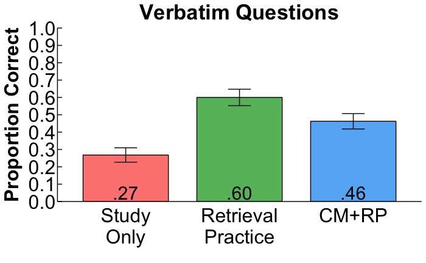

```r
E1data$cond <- factor(E1data$cond, levels = c("C", "B", "A")) # change order of condition for plotting
# create a table of means for plot annotations
E1verbMeans <- E1data %>%
  group_by(cond) %>%
  summarize(mean = mean(verbProportion)) %>%
  mutate(mean = apa(mean,2,F)) %>%  # false removes leading zero
  droplevels()
# create and store plot
E1.verbPlot <- ggplot(data = E1data, aes(x = cond, y = verbProportion, fill = cond)) +
  # ggplot code to create bar plots
    stat_summary(fun.y = mean, geom = 'bar', position = 'dodge', color = 'black', width = .75) +
    stat_summary(fun.data = mean_se, geom = 'errorbar',
                 position = position_dodge(width = .8), width = .2) +
  # label plot
    ggtitle("Verbatim Questions") + # label plot
    ylab('Proportion Correct')    + # y axis label
    xlab('')                      + # deletes x axis label
    scale_x_discrete(labels = c("Study\nOnly","Retrieval\nPractice","CM+RP"))+
  # color the bars
    scale_fill_manual(values=c("#FF8682","#66bb6a","#64b5f6")) +
  # add means to bars using annotation function, requires dataTable of means and their columnName
    annotations(E1verbMeans, "mean") +
  # y axis limits and tick marks
    coord_cartesian(ylim=c(0, 1.002)) +
    scale_y_continuous(expand = c(0,0), breaks=c(.0,.1,.2,.3,.4,.5,.6,.7,.8, .9, 1)) +
  # theme
    PCLLABtheme
E1.verbPlot # preview plot
```

## 7.2 - Higher order performance

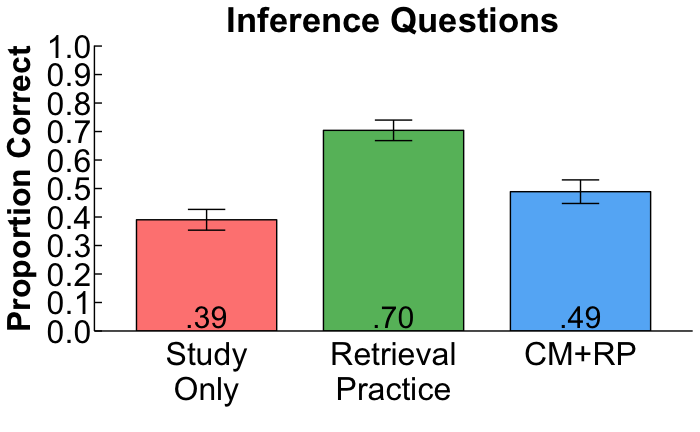

```r
E1data$cond <- factor(E1data$cond, levels = c("C", "B", "A")) # change order of condition for plotting
# create a table of means for plot annotations
E1higherMeans <- E1data %>%
  group_by(cond) %>%
  summarize(mean = mean(higherProportion)) %>%
  mutate(mean = apa(mean,2,F)) %>%  # false removes leading zero
  droplevels()
# create and store plot
E1.higherPlot <- ggplot(data = E1data, aes(x = cond, y = higherProportion, fill = cond)) +
  # ggplot code to create bar plots
    stat_summary(fun.y = mean, geom = 'bar', position = 'dodge', color = 'black', width = .75) +
    stat_summary(fun.data = mean_se, geom = 'errorbar',
                 position = position_dodge(width = .8), width = .2) +
  # label plot
    ggtitle("Inference Questions") + # label plot
    ylab('Proportion Correct')     + # y axis label
    xlab('')                       + # deletes x axis label
    scale_x_discrete(labels = c("Study\nOnly","Retrieval\nPractice","CM+RP"))+
  # color the bars
    scale_fill_manual(values=c("#FF8682","#66bb6a","#64b5f6")) +
  # add means to bars using annotation function, requires dataTable of means and their columnName
    annotations(E1higherMeans, "mean") +
  # y axis limits and tick marks
    coord_cartesian(ylim=c(0, 1.002)) +
    scale_y_continuous(expand = c(0,0), breaks=c(.0,.1,.2,.3,.4,.5,.6,.7,.8, .9, 1)) +
  # theme
    PCLLABtheme
E1.higherPlot # preview plot
```

## 7.3 - Recall performance

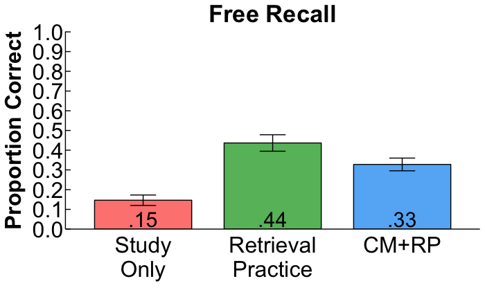

```r
E1data$cond <- factor(E1data$cond, levels = c("C", "B", "A")) # change order of condition for plotting
# create a table of means for plot annotations
E1r3Means <- E1data %>%
  group_by(cond) %>%
  summarize(mean = mean(r3Proportion)) %>%
  mutate(mean = apa(mean,2,F)) %>%  # false removes leading zero
  droplevels()
# create and store plot
E1.recall3Plot <- ggplot(data = E1data, aes(x = cond, y = r3Proportion, fill = cond)) +
  # ggplot code to create bar plots
    stat_summary(fun.y = mean, geom = 'bar', position = 'dodge', color = 'black', width = .75) +
    stat_summary(fun.data = mean_se, geom = 'errorbar',
                 position = position_dodge(width = .8), width = .2) +
  # label plot
    ggtitle("Free Recall")     + # label plot
    ylab('Proportion Correct') + # y axis label
    xlab('')                   + # deletes x axis label
    scale_x_discrete(labels = c("Study\nOnly","Retrieval\nPractice","CM+RP"))+
  # color the bars
    scale_fill_manual(values=c("#FF8682","#66bb6a","#64b5f6")) + # CM color for E2 #ffa47a
  # add means to bars using annotation function, requires dataTable of means and their columnName
    annotations(E1r3Means, "mean") +
  # y axis limits and tick marks
    coord_cartesian(ylim=c(0, 1.002)) +
    scale_y_continuous(expand = c(0,0), breaks=c(.0,.1,.2,.3,.4,.5,.6,.7,.8, .9, 1)) +
  # theme
    PCLLABtheme
E1.recall3Plot # preview plot
```

# 8 - Exploratory Analyses

## 8.1 - Input-output correspondence

```r
# descriptives
  kable(E1data %>%
    group_by(condition) %>%
    summarize(R1 = apa(mean(propForwardR1, na.rm = T),2),
              R2 = apa(mean(propForwardR2, na.rm = T),2),
              R3 = apa(mean(propForwardR3, na.rm = T),2)
              ), caption = "means") %>%
    kable_styling("condensed", full_width = F, font_size = 14, position = "left")
```

means

| condition | R1 | R2 | R3 |
| --- | --- | --- | --- |
| RP | 0.92 | 0.92 | 0.90 |
| CM+RP | 0.90 | 0.91 | 0.90 |
| Study | NaN | NaN | 0.86 |

```r
  kable(E1data %>%
    group_by(condition) %>%
    summarize(R1 = apa(sd(propForwardR1, na.rm = T),2),
              R2 = apa(sd(propForwardR2, na.rm = T),2),
              R3 = apa(sd(propForwardR3, na.rm = T),2)
              ), caption = "sd") %>%
    kable_styling("condensed", full_width = F, font_size = 14, position = "left")
```

sd

| condition | R1 | R2 | R3 |
| --- | --- | --- | --- |
| RP | 0.06 | 0.06 | 0.08 |
| CM+RP | 0.08 | 0.08 | 0.11 |
| Study | NA | NA | 0.14 |

```r
# R1
  kable(effSize(data = E1data %>% filter(condition == "RP"| condition == "CM+RP") %>% droplevels()
    , analysis = "between"            # within or between design
    , dataFormat = "wide"             # long or wide data
    , outcome = "propForwardR1"       # the outcome variable
    , predictor = "condition"         # the predictor predictor variable
    , n1 = 30                         # sample size for between-group designs
    , n2 = 28                         # sample size for between-group designs
    ), caption = "Proportion of Forward Transitions - Recall 1") %>%
    kable_styling("condensed", full_width = F, font_size = 14, position = "left")
```

Proportion of Forward Transitions - Recall 1

| t | df | p | d | dlow | dhigh | summary |
| --- | --- | --- | --- | --- | --- | --- |
| 1.44 | 56 | 0.154 | 0.38 | -0.14 | 0.90 | t(56) = 1.44, p = 0.154, d = 0.38 [-0.14, 0.90] |

```r
  # R2
  kable(effSize(data = E1data %>% filter(condition == "RP"| condition == "CM+RP")%>% droplevels()
    , analysis = "between"            # within or between design
    , dataFormat = "wide"             # long or wide data
    , outcome = "propForwardR2"       # the outcome variable
    , predictor = "condition"         # the predictor predictor variable
    , n1 = 28                         # sample size for between-group designs
    , n2 = 30                         # sample size for between-group designs
    ), caption = "Proportion of Forward Transitions - Recall 2") %>%
    kable_styling("condensed", full_width = F, font_size = 14, position = "left")
```

Proportion of Forward Transitions - Recall 2

| t | df | p | d | dlow | dhigh | summary |
| --- | --- | --- | --- | --- | --- | --- |
| 0.67 | 56 | 0.503 | 0.18 | -0.34 | 0.69 | t(56) = 0.67, p = 0.503, d = 0.18 [-0.34, 0.69] |

```r
# R3
  kable(effSize(data = E1data %>% filter(condition == "RP"| condition == "CM+RP") %>%  droplevels()
    , analysis = "between"            # within or between design
    , dataFormat = "wide"             # long or wide data
    , outcome = "propForwardR3"       # the outcome variable
    , predictor = "condition"         # the predictor predictor variable
    , n1 = 30                         # sample size for between-group designs
    , n2 = 28                         # sample size for between-group designs
    ), caption = "Proportion of Forward Transitions - Recall 3") %>%
    kable_styling("condensed", full_width = F, font_size = 14, position = "left")
```

Proportion of Forward Transitions - Recall 3

| t | df | p | d | dlow | dhigh | summary |
| --- | --- | --- | --- | --- | --- | --- |
| -0.21 | 56 | 0.836 | -0.05 | -0.57 | 0.46 | t(56) = -0.21, p = 0.836, d = -0.05 [-0.57, 0.46] |

## 8.2 - Conditional recall analysis

```r
# descriptives
  kable(E1data %>%
    filter(cond != "C") %>%
    group_by(condition) %>%
    summarize(CC = apa(mean(CC, na.rm = T),2),
              CN = apa(mean(CN, na.rm = T),2),
              NC = apa(mean(NC, na.rm = T),2),
              NN = apa(mean(NN, na.rm = T),2)
              ), caption = "means") %>%
    kable_styling("condensed", full_width = F, font_size = 14, position = "left")
```

means

| condition | CC | CN | NC | NN |
| --- | --- | --- | --- | --- |
| RP | 0.36 | 0.05 | 0.28 | 0.31 |
| CM+RP | 0.42 | 0.07 | 0.19 | 0.32 |

```r
  kable(E1data %>%
    filter(cond != "C") %>%
    group_by(condition) %>%
    summarize(CC = apa(sd(CC, na.rm = T),2),
              CN = apa(sd(CN, na.rm = T),2),
              NC = apa(sd(NC, na.rm = T),2),
              NN = apa(sd(NN, na.rm = T),2)
              ), caption = "sds") %>%
    kable_styling("condensed", full_width = F, font_size = 14, position = "left")
```

sds

| condition | CC | CN | NC | NN |
| --- | --- | --- | --- | --- |
| RP | 0.21 | 0.06 | 0.11 | 0.21 |
| CM+RP | 0.18 | 0.05 | 0.11 | 0.17 |

```r
# CC
  kable(effSize(data = E1data %>% filter(condition == "RP"| condition == "CM+RP") %>% droplevels()
    , analysis = "between"            # within or between design
    , dataFormat = "wide"             # long or wide data
    , outcome = "CC"                  # the outcome variable
    , predictor = "condition"         # the predictor predictor variable
    , n1 = 30                         # sample size for between-group designs
    , n2 = 30                         # sample size for between-group designs
    ), caption = "CC") %>%
    kable_styling("condensed", full_width = F, font_size = 14, position = "left")
```

CC

| t | df | p | d | dlow | dhigh | summary |
| --- | --- | --- | --- | --- | --- | --- |
| -1.33 | 58 | 0.190 | -0.34 | -0.85 | 0.17 | t(58) = -1.33, p = 0.190, d = -0.34 [-0.85, 0.17] |

```r
  # CN
  kable(effSize(data = E1data %>% filter(condition == "RP"| condition == "CM+RP") %>% droplevels()
    , analysis = "between"            # within or between design
    , dataFormat = "wide"             # long or wide data
    , outcome = "CN"                  # the outcome variable
    , predictor = "condition"         # the predictor predictor variable
    , n1 = 30                         # sample size for between-group designs
    , n2 = 30                         # sample size for between-group designs
    ), caption = "CN") %>%
    kable_styling("condensed", full_width = F, font_size = 14, position = "left")
```

CN

| t | df | p | d | dlow | dhigh | summary |
| --- | --- | --- | --- | --- | --- | --- |
| -1.12 | 58 | 0.268 | -0.29 | -0.80 | 0.22 | t(58) = -1.12, p = 0.268, d = -0.29 [-0.80, 0.22] |

```r
# NC
  kable(effSize(data = E1data %>% filter(condition == "RP"| condition == "CM+RP") %>% droplevels()
    , analysis = "between"            # within or between design
    , dataFormat = "wide"             # long or wide data
    , outcome = "NC"                  # the outcome variable
    , predictor = "condition"         # the predictor predictor variable
    , n1 = 30                         # sample size for between-group designs
    , n2 = 30                         # sample size for between-group designs
    ), caption = "NC") %>%
    kable_styling("condensed", full_width = F, font_size = 14, position = "left")
```

NC

| t | df | p | d | dlow | dhigh | summary |
| --- | --- | --- | --- | --- | --- | --- |
| 3.13 | 58 | 0.003 | 0.81 | 0.28 | 1.33 | t(58) = 3.13, p = 0.003, d = 0.81 [0.28, 1.33] |

```r
# NN
  kable(effSize(data = E1data %>% filter(condition == "RP"| condition == "CM+RP") %>% droplevels()
    , analysis = "between"            # within or between design
    , dataFormat = "wide"             # long or wide data
    , outcome = "NN"                  # the outcome variable
    , predictor = "condition"         # the predictor predictor variable
    , n1 = 30                         # sample size for between-group designs
    , n2 = 30                         # sample size for between-group designs
    ), caption = "NN") %>%
    kable_styling("condensed", full_width = F, font_size = 14, position = "left")
```

NN

| t | df | p | d | dlow | dhigh | summary |
| --- | --- | --- | --- | --- | --- | --- |
| -0.16 | 58 | 0.872 | -0.04 | -0.55 | 0.46 | t(58) = -0.16, p = 0.872, d = -0.04 [-0.55, 0.46] |